# R Notebook

## ======================= Import Libraries & Load Data ========================

```r
library(data.table)
library(ggplot2)
library(glmnet)
library(caret)
library(randomForest)
library(class)
library(e1071)
library(MASS)

dataset = fread('diabetes_binary_5050split_health_indicators_BRFSS2015.csv')

dataset$Diabetes_binary = as.factor(dataset$Diabetes_binary)
head(dataset, 5)
```

| Diabetes_binary | HighBP | HighChol | CholCheck | BMI | Smoker | Stroke | HeartDiseaseorAttack | PhysActivity | Fruits | Veggies | HvyAlcoholConsump | AnyHealthcare | NoDocbcCost | GenHlth | MentHlth | PhysHlth | DiffWalk | Sex | Age | Education | Income |
| --- | --- | --- | --- | --- | --- | --- | --- | --- | --- | --- | --- | --- | --- | --- | --- | --- | --- | --- | --- | --- | --- |
| 0 | 1 | 0 | 1 | 26 | 0 | 0 | 0 | 1 | 0 | 1 | 0 | 1 | 0 | 3 | 5 | 30 | 0 | 1 | 4 | 6 | 8 |
| 0 | 1 | 1 | 1 | 26 | 1 | 1 | 0 | 0 | 1 | 0 | 0 | 1 | 0 | 3 | 0 | 0 | 0 | 1 | 12 | 6 | 8 |
| 0 | 0 | 0 | 1 | 26 | 0 | 0 | 0 | 1 | 1 | 1 | 0 | 1 | 0 | 1 | 0 | 10 | 0 | 1 | 13 | 6 | 8 |
| 0 | 1 | 1 | 1 | 28 | 1 | 0 | 0 | 1 | 1 | 1 | 0 | 1 | 0 | 3 | 0 | 3 | 0 | 1 | 11 | 6 | 8 |
| 0 | 0 | 0 | 1 | 29 | 1 | 0 | 0 | 1 | 1 | 1 | 0 | 1 | 0 | 2 | 0 | 0 | 0 | 0 | 8 | 5 | 8 |

## ================================ Question 1 =================================

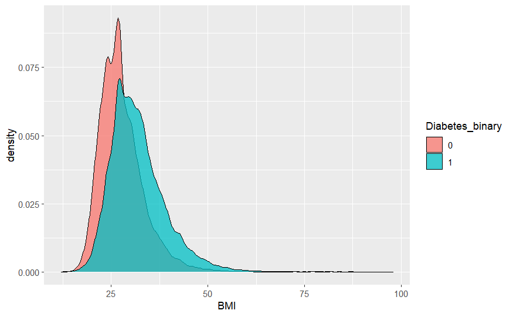

```r
ggplot(dataset, aes(BMI, fill = Diabetes_binary))+
  geom_density(alpha = .75)
```

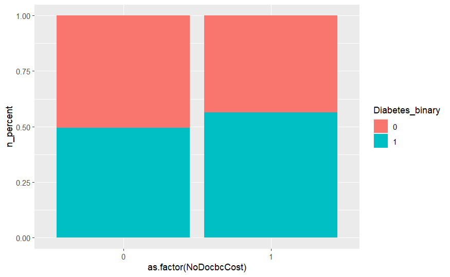

```r
dataset$one = 1
ds = dataset[, .(n = sum(one)), .(Diabetes_binary, NoDocbcCost)]
ds[, n_total := sum(n), .(NoDocbcCost)]
ds[, n_percent := n / n_total]

ggplot(ds, aes(as.factor(NoDocbcCost), n_percent, fill = Diabetes_binary))+
  geom_bar(stat = 'identity', )
```

```r
summary(dataset)
```

```
 Diabetes_binary     HighBP          HighChol        CholCheck           BMI
 0:35346         Min.   :0.0000   Min.   :0.0000   Min.   :0.0000   Min.   :12.00
 1:35346         1st Qu.:0.0000   1st Qu.:0.0000   1st Qu.:1.0000   1st Qu.:25.00
                 Median :1.0000   Median :1.0000   Median :1.0000   Median :29.00
                 Mean   :0.5635   Mean   :0.5257   Mean   :0.9753   Mean   :29.86
                 3rd Qu.:1.0000   3rd Qu.:1.0000   3rd Qu.:1.0000   3rd Qu.:33.00
                 Max.   :1.0000   Max.   :1.0000   Max.   :1.0000   Max.   :98.00
     Smoker           Stroke        HeartDiseaseorAttack  PhysActivity       Fruits
 Min.   :0.0000   Min.   :0.00000   Min.   :0.0000       Min.   :0.000   Min.   :0.0000
 1st Qu.:0.0000   1st Qu.:0.00000   1st Qu.:0.0000       1st Qu.:0.000   1st Qu.:0.0000
 Median :0.0000   Median :0.00000   Median :0.0000       Median :1.000   Median :1.0000
 Mean   :0.4753   Mean   :0.06217   Mean   :0.1478       Mean   :0.703   Mean   :0.6118
 3rd Qu.:1.0000   3rd Qu.:0.00000   3rd Qu.:0.0000       3rd Qu.:1.000   3rd Qu.:1.0000
 Max.   :1.0000   Max.   :1.00000   Max.   :1.0000       Max.   :1.000   Max.   :1.0000
    Veggies       HvyAlcoholConsump AnyHealthcare    NoDocbcCost         GenHlth
 Min.   :0.0000   Min.   :0.00000   Min.   :0.000   Min.   :0.00000   Min.   :1.000
 1st Qu.:1.0000   1st Qu.:0.00000   1st Qu.:1.000   1st Qu.:0.00000   1st Qu.:2.000
 Median :1.0000   Median :0.00000   Median :1.000   Median :0.00000   Median :3.000
 Mean   :0.7888   Mean   :0.04272   Mean   :0.955   Mean   :0.09391   Mean   :2.837
 3rd Qu.:1.0000   3rd Qu.:0.00000   3rd Qu.:1.000   3rd Qu.:0.00000   3rd Qu.:4.000
 Max.   :1.0000   Max.   :1.00000   Max.   :1.000   Max.   :1.00000   Max.   :5.000
    MentHlth         PhysHlth        DiffWalk           Sex             Age
 Min.   : 0.000   Min.   : 0.00   Min.   :0.0000   Min.   :0.000   Min.   : 1.000
 1st Qu.: 0.000   1st Qu.: 0.00   1st Qu.:0.0000   1st Qu.:0.000   1st Qu.: 7.000
 Median : 0.000   Median : 0.00   Median :0.0000   Median :0.000   Median : 9.000
 Mean   : 3.752   Mean   : 5.81   Mean   :0.2527   Mean   :0.457   Mean   : 8.584
 3rd Qu.: 2.000   3rd Qu.: 6.00   3rd Qu.:1.0000   3rd Qu.:1.000   3rd Qu.:11.000
 Max.   :30.000   Max.   :30.00   Max.   :1.0000   Max.   :1.000   Max.   :13.000
   Education         Income           one
 Min.   :1.000   Min.   :1.000   Min.   :1
 1st Qu.:4.000   1st Qu.:4.000   1st Qu.:1
 Median :5.000   Median :6.000   Median :1
 Mean   :4.921   Mean   :5.698   Mean   :1
 3rd Qu.:6.000   3rd Qu.:8.000   3rd Qu.:1
 Max.   :6.000   Max.   :8.000   Max.   :1
```

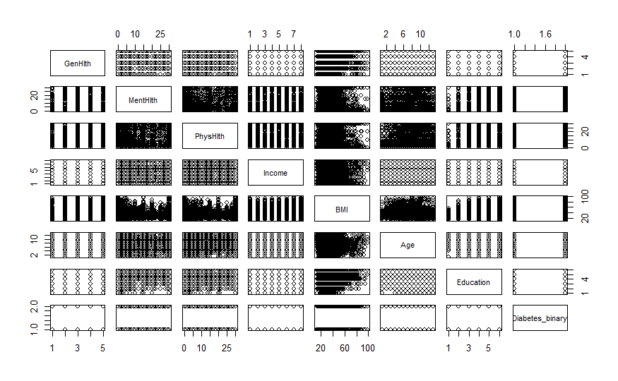

```r
pairs(dataset[, c("GenHlth", "MentHlth", "PhysHlth", "Income", "BMI", "Age", "Education", "Diabetes_binary")])
```

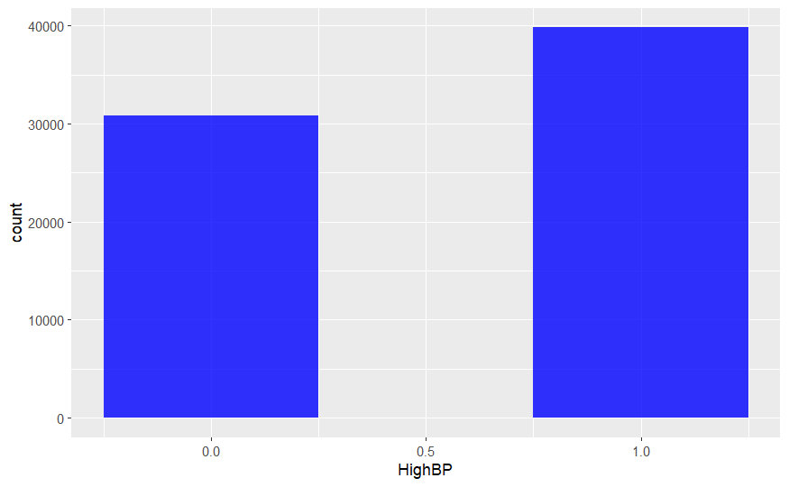

```r
# Histogram of HighBP
ggplot(dataset, aes(x = HighBP)) +
  geom_histogram(fill = "blue", binwidth = 0.5, alpha = 0.8)
```

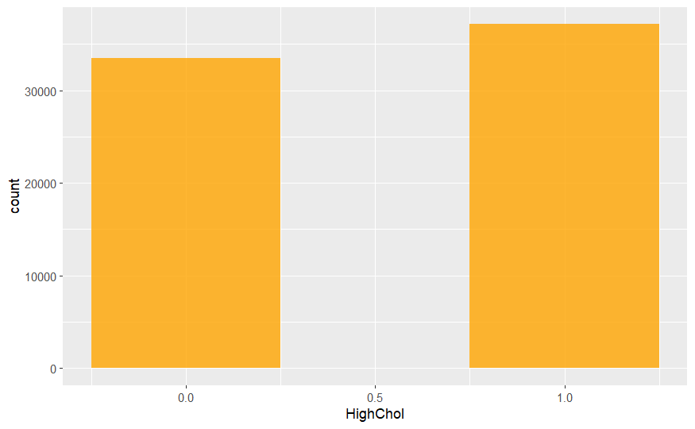

```r
# Histogram of HighChol
ggplot(dataset, aes(x = HighChol)) +
  geom_histogram(fill = "orange", binwidth = 0.5, alpha = 0.8)
```

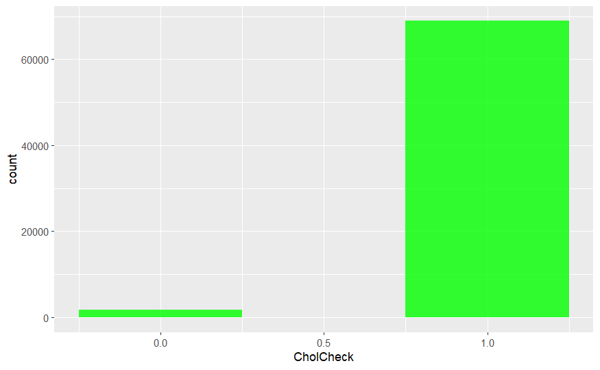

```r
# Histogram of CholCheck
ggplot(dataset, aes(x = CholCheck)) +
  geom_histogram(fill = "green", binwidth = 0.5, alpha = 0.8)
```

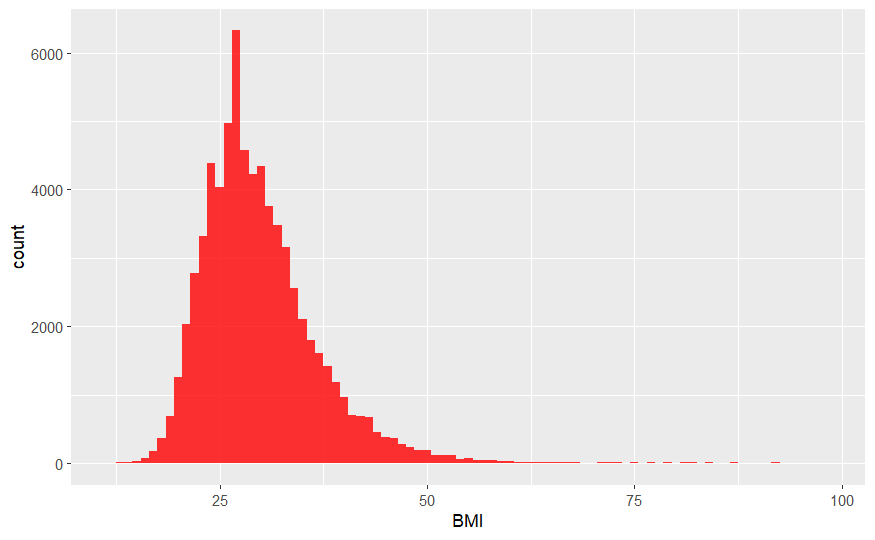

```r
# Histogram of BMI
ggplot(dataset, aes(x = BMI)) +
  geom_histogram(fill = "red", binwidth = 1, alpha = 0.8)
```

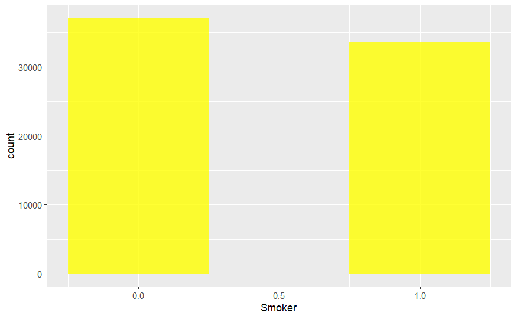

```r
# Histogram of CholCheck
ggplot(dataset, aes(x = Smoker)) +
  geom_histogram(fill = "yellow", binwidth = 0.5, alpha = 0.8)
```

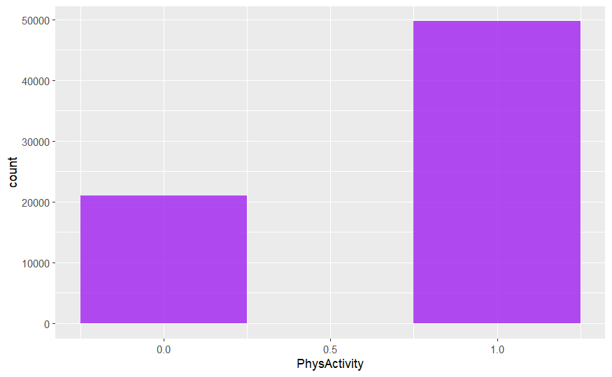

```r
# Histogram of PhysActivity
ggplot(dataset, aes(x = PhysActivity)) +
  geom_histogram(fill = "purple", binwidth = 0.5, alpha = 0.8)
```

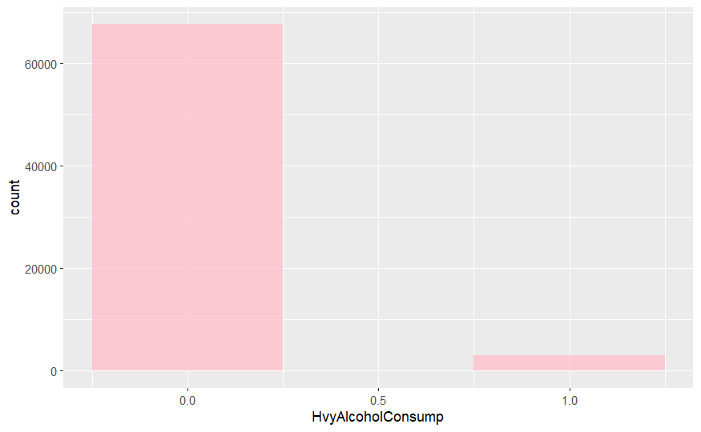

```r
# Histogram of HvyAlcoholConsump
ggplot(dataset, aes(x = HvyAlcoholConsump)) +
  geom_histogram(fill = "pink", binwidth = 0.5, alpha = 0.8)
```

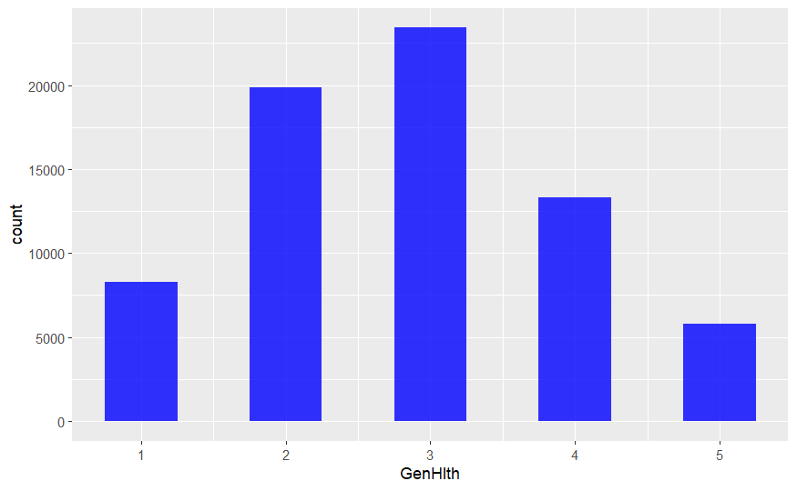

```r
# Histogram of GenHlth
ggplot(dataset, aes(x = GenHlth)) +
  geom_histogram(fill = "blue", binwidth = 0.5, alpha = 0.8)
```

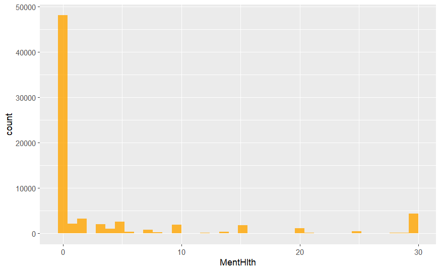

```r
# Histogram of MentHlth
ggplot(dataset, aes(x = MentHlth)) +
  geom_histogram(fill = "orange", binwidth = 0.8, alpha = 0.8)
```

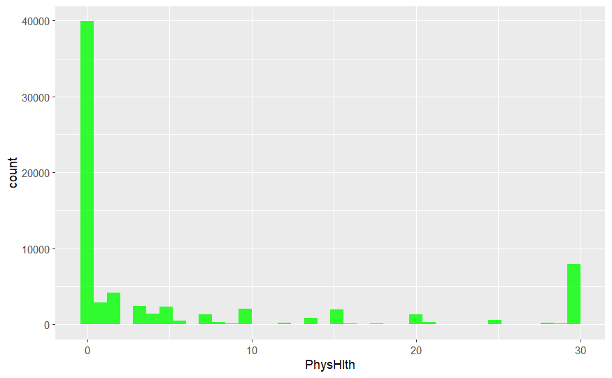

```r
# Histogram of PhysHlth
ggplot(dataset, aes(x = PhysHlth)) +
  geom_histogram(fill = "green", binwidth = 0.8, alpha = 0.8)
```

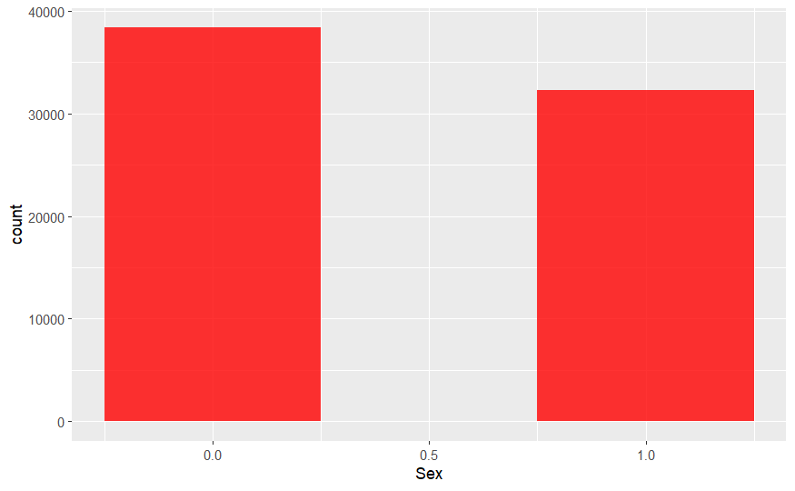

```r
# Histogram of Sex
ggplot(dataset, aes(x = Sex)) +
  geom_histogram(fill = "red", binwidth = 0.5, alpha = 0.8)
```

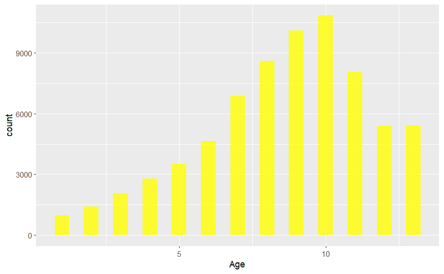

```r
# Histogram of Age
ggplot(dataset, aes(x = Age)) +
  geom_histogram(fill = "yellow", binwidth = 0.5, alpha = 0.8)
```

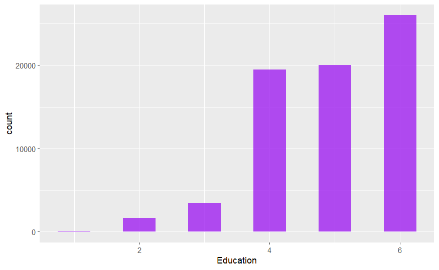

```r
# Histogram of Education
ggplot(dataset, aes(x = Education)) +
  geom_histogram(fill = "purple", binwidth = 0.5, alpha = 0.8)
```

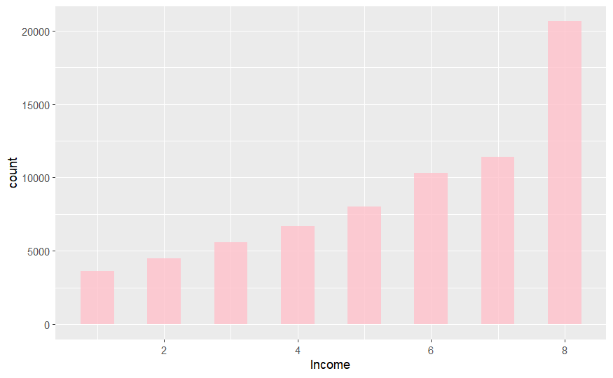

```r
# Histogram of Income
ggplot(dataset, aes(x = Income)) +
  geom_histogram(fill = "pink", binwidth = 0.5, alpha = 0.8)
```

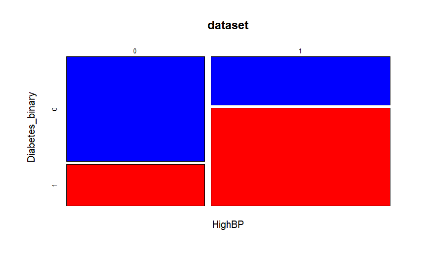

```r
color = c("blue", "red")

mosaicplot(HighBP ~ Diabetes_binary, data = dataset, color=color)
```

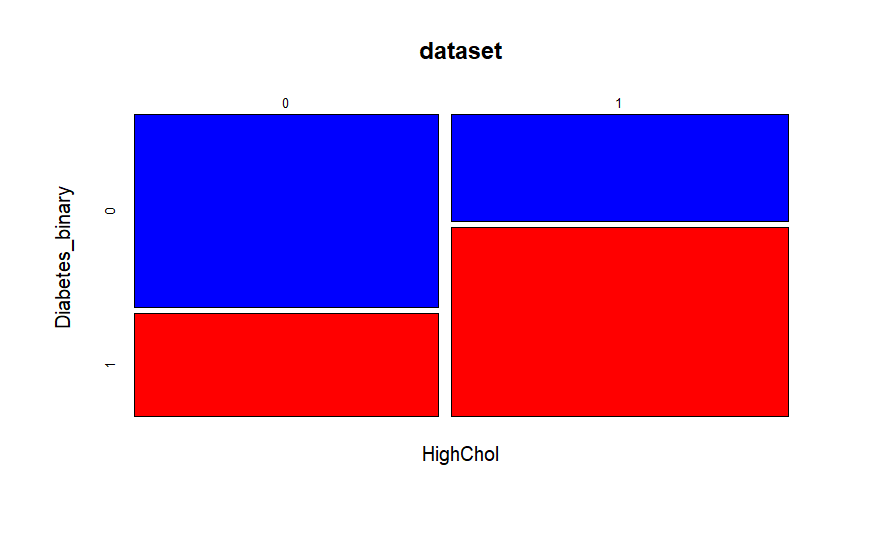

```r
mosaicplot(HighChol ~ Diabetes_binary, data = dataset, color=color)
```

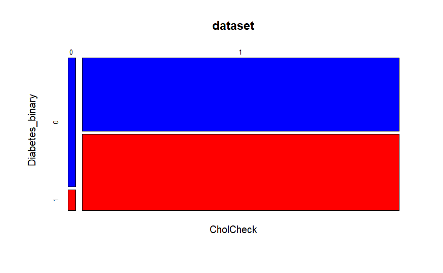

```r
mosaicplot(CholCheck ~ Diabetes_binary, data = dataset, color=color)
```

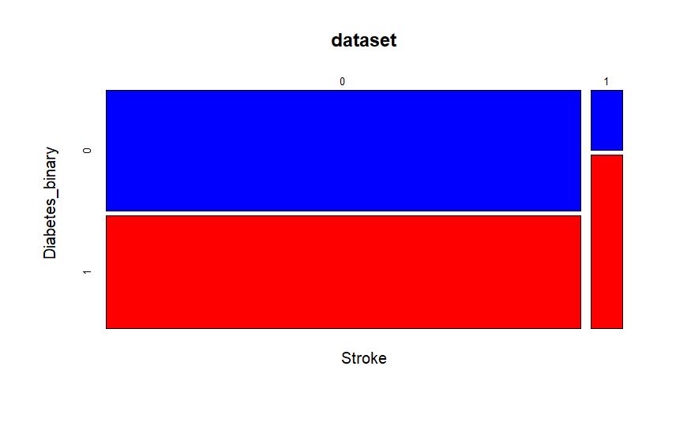

```r
mosaicplot(Stroke ~ Diabetes_binary, data = dataset, color=color)
```

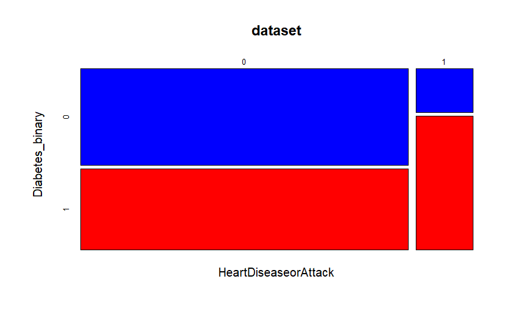

```r
mosaicplot(HeartDiseaseorAttack ~ Diabetes_binary, data = dataset, color=color)
```

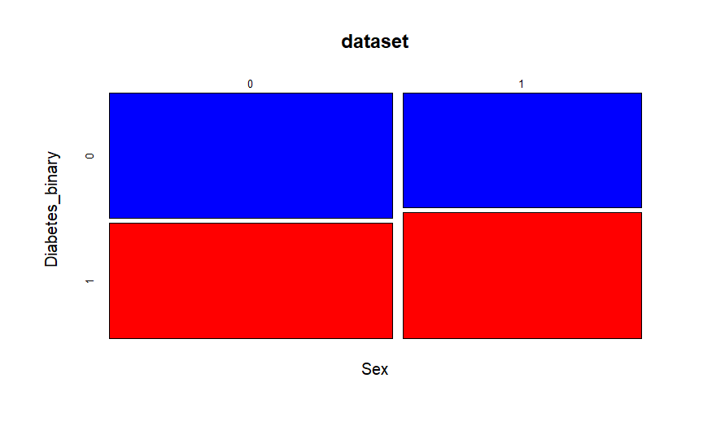

```r
mosaicplot(Sex ~ Diabetes_binary, data = dataset, color=color)
```

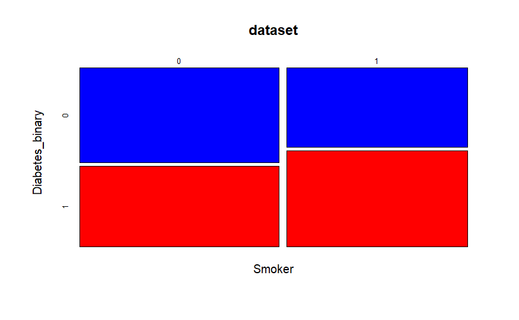

```r
mosaicplot(Smoker ~ Diabetes_binary, data = dataset, color=color)
```

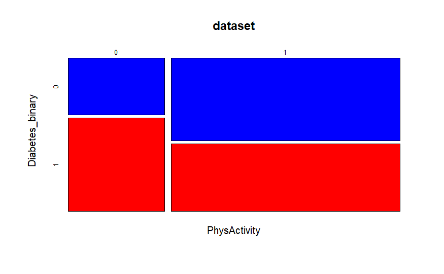

```r
mosaicplot(PhysActivity ~ Diabetes_binary, data = dataset, color=color)
```

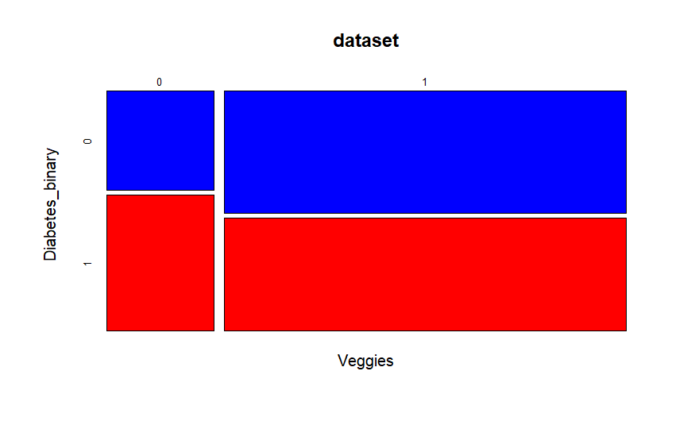

```r
mosaicplot(Veggies ~ Diabetes_binary, data = dataset, color=color)
```

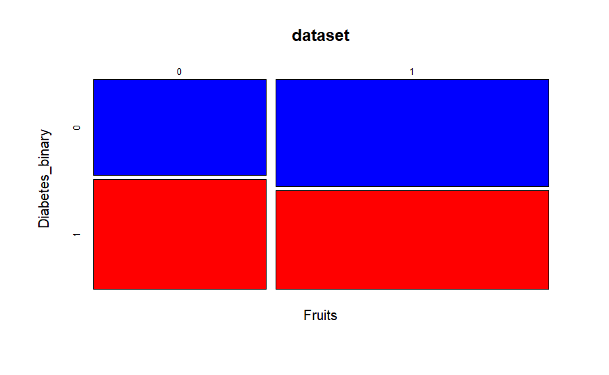

```r
mosaicplot(Fruits ~ Diabetes_binary, data = dataset, color=color)
```

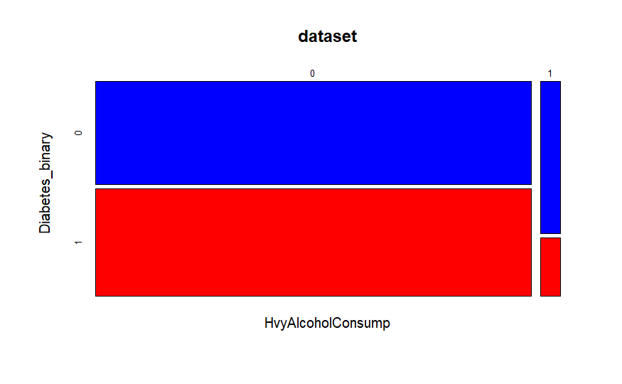

```r
mosaicplot(HvyAlcoholConsump ~ Diabetes_binary, data = dataset, color=color)
```

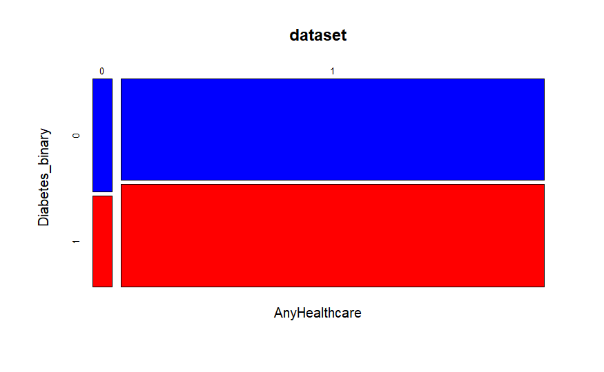

```r
mosaicplot(AnyHealthcare ~ Diabetes_binary, data = dataset, color=color)
```

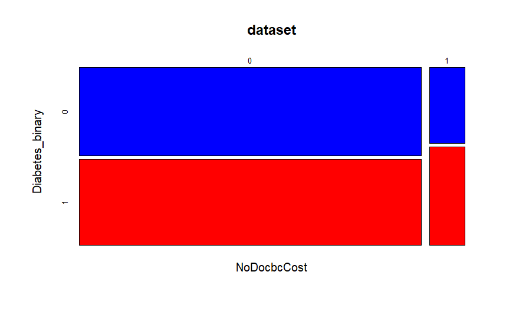

```r
mosaicplot(NoDocbcCost ~ Diabetes_binary, data = dataset, color=color)
```

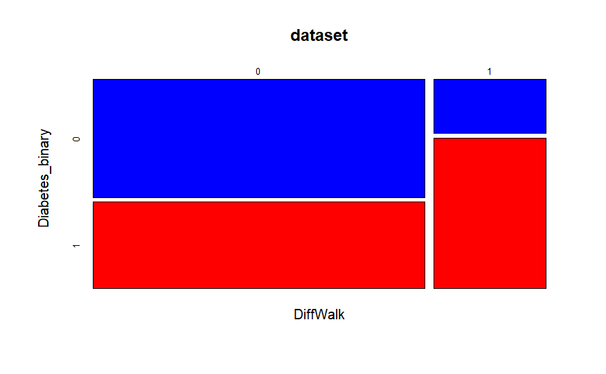

```r
mosaicplot(DiffWalk ~ Diabetes_binary, data = dataset, color=color)
```

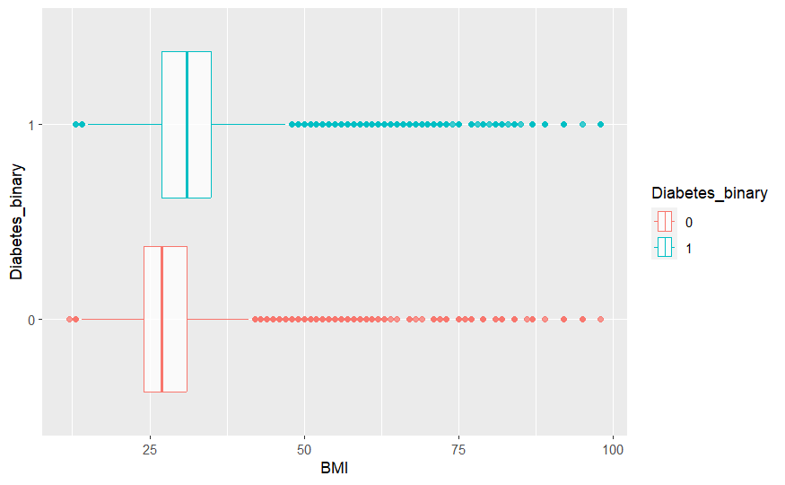

```r
# Boxplot of BMI by diabetes status
ggplot(dataset, aes(x = BMI, y = Diabetes_binary, color = Diabetes_binary, group = Diabetes_binary)) +
  geom_boxplot(alpha = 0.75)
```

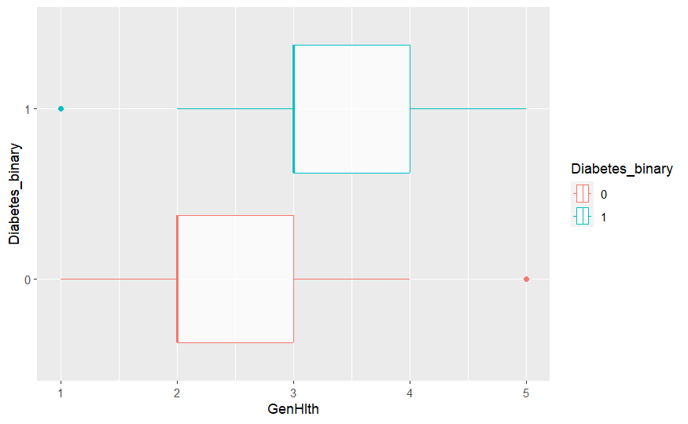

```r
# Boxplot of GenHlth by diabetes status
ggplot(dataset, aes(x = GenHlth, y = Diabetes_binary, color = Diabetes_binary, group = Diabetes_binary)) +
  geom_boxplot(alpha = 0.75)
```

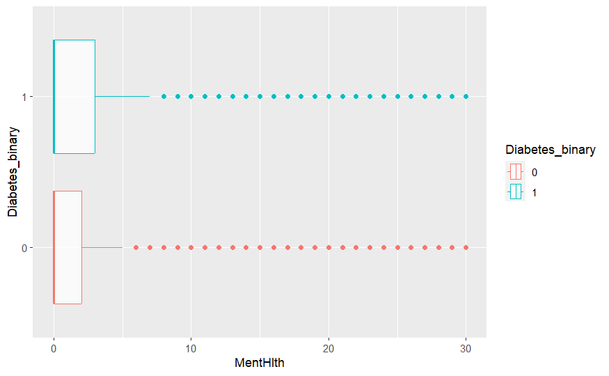

```r
# Boxplot of MentHlth by diabetes status
ggplot(dataset, aes(x = MentHlth, y = Diabetes_binary, color = Diabetes_binary, group = Diabetes_binary)) +
  geom_boxplot(alpha = 0.75)
```

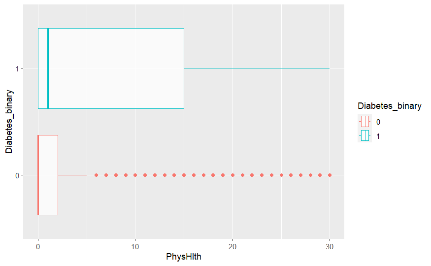

```r
# Boxplot of PhysHlth by diabetes status
ggplot(dataset, aes(x = PhysHlth, y = Diabetes_binary, color = Diabetes_binary, group = Diabetes_binary)) +
  geom_boxplot(alpha = 0.75)
```

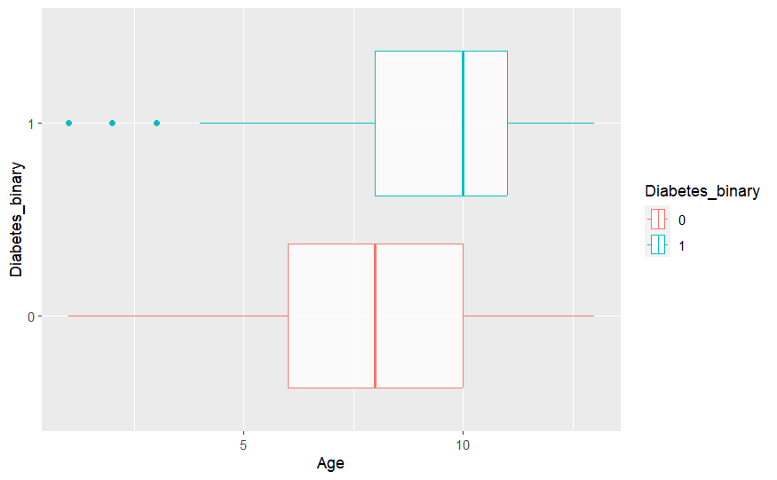

```r
# Boxplot of Age by diabetes status
ggplot(dataset, aes(x = Age, y = Diabetes_binary, color = Diabetes_binary, group = Diabetes_binary)) +
  geom_boxplot(alpha = 0.75)
```

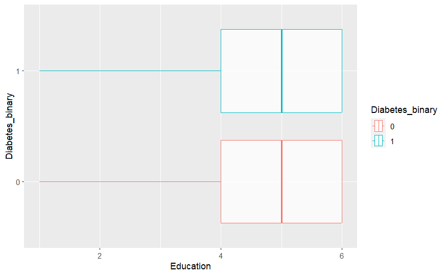

```r
# Boxplot of Education by diabetes status
ggplot(dataset, aes(x = Education, y = Diabetes_binary, color = Diabetes_binary, group = Diabetes_binary)) +
  geom_boxplot(alpha = 0.75)
```

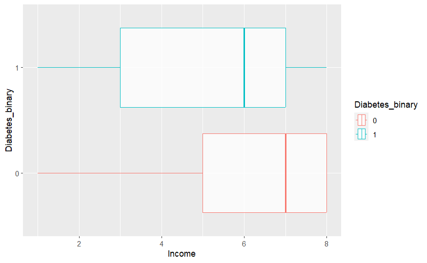

```r
# Boxplot of Income by diabetes status
ggplot(dataset, aes(x = Income, y = Diabetes_binary, color = Diabetes_binary, group = Diabetes_binary)) +
  geom_boxplot(alpha = 0.75)
```

Histogram: A histogram is a graphical representation of the distribution of a continuous or discrete variable. It consists of a series of adjacent rectangular bars, where the width of each bar represents a range of values, and the height represents the frequency or count of observations falling within that range. Histograms provide insights into the shape, center, and spread of the data distribution. They are particularly useful for visualizing the density or frequency of values within different intervals or bins. Histograms can help identify patterns such as skewness, multimodality, and outliers in the data.

MasiacPlot: A mosaic plot is a graphical representation that displays the relationship between two or more categorical variables. It consists of rectangular tiles, where the area of each tile is proportional to the count or percentage of observations falling into a specific combination of categories. Mosaic plots can be useful for exploring the associations and dependencies between categorical variables. They provide a visual representation of how the frequencies or proportions of different categories are distributed across the combinations of variables, allowing for easy identification of patterns and relationships.

Based on these graphs, Some features like HighBP, HighChol, CholCheck, Stroke, HeartDiseaseorAttack, PhysActivit, HvyAlcoholConsump and DiffWalk have clear effect on diabetes.

Barplot: A boxplot, also known as a box-and-whisker plot, is a graphical representation of the distribution of a numerical variable. It displays key statistical measures such as the median, quartiles, and potential outliers. The box in the plot represents the interquartile range (IQR), which contains the middle 50% of the data. The line within the box represents the median. The whiskers extend to the minimum and maximum values within a certain range (usually 1.5 times the IQR), and outliers are depicted as individual data points beyond the whiskers. Boxplots are useful for identifying the central tendency, spread, and skewness of a dataset.

Based on these charts, the effect of Age, BMI, Income, PhysHlth and GenHlth is clear on diabetes.

In conclusoin, as some features are somehow related to diabetes, we can hope there will be a good model to estimate the diabetes based on these data and features.

## ============================== Question 2 & 3 & 4 =============================

To determine which features in the dataset have the most predictive power for diabetes, we can use feature selection techniques. One common method for feature selection is to calculate the feature importance or coefficient values from a logistic regression model. The absolute values of the coefficients indicate the strength of association between each feature and the target variable.

We split the data into a 70% training set and a 30% test set. The validation measurements we utilize include accuracy, AIC, RSS, or MSE. The models are logistic regression, random forest, KNN, LDA

```r
# Load dataset
data <- read.csv("diabetes_binary_5050split_health_indicators_BRFSS2015.csv")

# Shuffle the dataset
set.seed(123)
shuffled_data <- data[sample(nrow(data)), ]

# Split the shuffled data into training and testing sets
train_ratio <- 0.7  # Set the desired training set ratio
train_indices <- createDataPartition(shuffled_data$Diabetes_binary, p = train_ratio, list = FALSE)
train_data <- shuffled_data[train_indices, ]
test_data <- shuffled_data[-train_indices, ]
```

```r
# Create a logistic regression model
logistic_model <- glm(Diabetes_binary ~ ., data = train_data, family = binomial)
logistic_predictions <- predict(logistic_model, newdata = test_data, type = "response")
summary_data <- summary(logistic_model)

# Extract p-values for each feature
p_values <- summary_data$coefficients[, "Pr(>|z|)"]

# Extract feature coefficients and their names
coefficients <- coef(logistic_model)[-1]  # Exclude the intercept
feature_names <- names(coefficients)

# Sort the coefficients by absolute value in descending order
sorted_indices <- order(abs(coefficients), decreasing = TRUE)
sorted_coefficients <- coefficients[sorted_indices]
sorted_feature_names <- feature_names[sorted_indices]

# Print the feature names and their corresponding coefficients
for (i in seq_along(sorted_coefficients)) {
  feature <- sorted_feature_names[i]
  coefficient <- sorted_coefficients[i]
  p_value <- p_values[feature]
  cat("Feature:", feature, ",\tCoefficient:", round(coefficient, 5), ",\tp_value:", p_value, "\n")
}
```

```
Feature: CholCheck ,    Coefficient: 1.33945 ,  p_value: 8.003448e-45
Feature: HighBP ,   Coefficient: 0.73896 ,  p_value: 1.546514e-215
Feature: HvyAlcoholConsump ,    Coefficient: -0.72016 , p_value: 8.765909e-35
Feature: HighChol , Coefficient: 0.5945 ,   p_value: 1.175477e-153
Feature: GenHlth ,  Coefficient: 0.58901 ,  p_value: 0
Feature: Sex ,  Coefficient: 0.26085 ,  p_value: 3.875574e-30
Feature: HeartDiseaseorAttack , Coefficient: 0.23547 ,  p_value: 3.173632e-12
Feature: Age ,  Coefficient: 0.15164 ,  p_value: 2.815956e-231
Feature: Stroke ,   Coefficient: 0.14905 ,  p_value: 0.002184086
Feature: AnyHealthcare ,    Coefficient: 0.11372 ,  p_value: 0.04426042
Feature: DiffWalk , Coefficient: 0.08129 ,  p_value: 0.0084467
Feature: BMI ,  Coefficient: 0.07554 ,  p_value: 0
Feature: Fruits ,   Coefficient: -0.05768 , p_value: 0.0134656
Feature: Income ,   Coefficient: -0.0568 ,  p_value: 4.165624e-20
Feature: Veggies ,  Coefficient: -0.0499 ,  p_value: 0.07213604
Feature: Education ,    Coefficient: -0.04165 , p_value: 0.0006345927
Feature: PhysActivity , Coefficient: -0.03642 , p_value: 0.1515049
Feature: Smoker ,   Coefficient: -0.02471 , p_value: 0.2730046
Feature: NoDocbcCost ,  Coefficient: 0.01289 ,  p_value: 0.7501284
Feature: PhysHlth , Coefficient: -0.00802 , p_value: 1.910118e-08
Feature: MentHlth , Coefficient: -0.00312 , p_value: 0.04244233
```

it is possible to use a subset of predictors and ignore others. This approach is known as feature selection, where you select a subset of relevant predictors that have the most predictive power for your target variable.

One common method for feature selection is called “stepwise selection,” which iteratively adds or removes predictors based on their significance or performance in the model.

Feature selection methods like stepwise selection have their limitations and may not always yield the optimal subset of predictors. It’s a good practice to combine feature selection techniques with domain knowledge and consider alternative approaches like regularization methods (e.g., Lasso or Ridge regression) or ensemble methods (e.g., random forests) to select relevant predictors.

Here is the stepwise feature selection:

```r
# Create a logistic regression model with stepwise feature selection
model <- step(glm(Diabetes_binary ~ ., data = train_data), direction = "both", trace = TRUE)
```

```
Start:  AIC=53673.17
Diabetes_binary ~ HighBP + HighChol + CholCheck + BMI + Smoker +
    Stroke + HeartDiseaseorAttack + PhysActivity + Fruits + Veggies +
    HvyAlcoholConsump + AnyHealthcare + NoDocbcCost + GenHlth +
    MentHlth + PhysHlth + DiffWalk + Sex + Age + Education +
    Income

                       Df Deviance   AIC
- NoDocbcCost           1   8563.4 53671
<none>                      8563.4 53673
- Smoker                1   8563.8 53673
- PhysActivity          1   8563.9 53674
- Veggies               1   8564.0 53675
- Fruits                1   8564.3 53676
- AnyHealthcare         1   8564.4 53677
- MentHlth              1   8564.6 53678
- Stroke                1   8564.8 53679
- Education             1   8565.5 53683
- DiffWalk              1   8566.3 53688
- PhysHlth              1   8570.2 53711
- HeartDiseaseorAttack  1   8574.7 53737
- Income                1   8580.8 53772
- Sex                   1   8584.7 53794
- HvyAlcoholConsump     1   8589.6 53822
- CholCheck             1   8594.6 53851
- HighChol              1   8691.9 54409
- Age                   1   8744.5 54707
- HighBP                1   8782.5 54922
- BMI                   1   8865.5 55387
- GenHlth               1   8925.7 55722

Step:  AIC=53671.22
Diabetes_binary ~ HighBP + HighChol + CholCheck + BMI + Smoker +
    Stroke + HeartDiseaseorAttack + PhysActivity + Fruits + Veggies +
    HvyAlcoholConsump + AnyHealthcare + GenHlth + MentHlth +
    PhysHlth + DiffWalk + Sex + Age + Education + Income

                       Df Deviance   AIC
<none>                      8563.4 53671
- Smoker                1   8563.8 53671
- PhysActivity          1   8563.9 53672
- Veggies               1   8564.1 53673
+ NoDocbcCost           1   8563.4 53673
- Fruits                1   8564.3 53674
- AnyHealthcare         1   8564.5 53675
- MentHlth              1   8564.7 53677
- Stroke                1   8564.8 53677
- Education             1   8565.5 53682
- DiffWalk              1   8566.3 53686
- PhysHlth              1   8570.3 53709
- HeartDiseaseorAttack  1   8574.8 53735
- Income                1   8580.9 53770
- Sex                   1   8584.7 53792
- HvyAlcoholConsump     1   8589.6 53820
- CholCheck             1   8594.7 53850
- HighChol              1   8692.0 54407
- Age                   1   8747.7 54723
- HighBP                1   8782.5 54920
- BMI                   1   8865.6 55385
- GenHlth               1   8926.3 55723
```

```r
summary(model)
```

```
Call:
glm(formula = Diabetes_binary ~ HighBP + HighChol + CholCheck +
    BMI + Smoker + Stroke + HeartDiseaseorAttack + PhysActivity +
    Fruits + Veggies + HvyAlcoholConsump + AnyHealthcare + GenHlth +
    MentHlth + PhysHlth + DiffWalk + Sex + Age + Education +
    Income, data = train_data)

Coefficients:
                       Estimate Std. Error t value Pr(>|t|)
(Intercept)          -0.5939599  0.0206770 -28.726  < 2e-16 ***
HighBP                0.1562089  0.0043905  35.579  < 2e-16 ***
HighChol              0.1107745  0.0040649  27.252  < 2e-16 ***
CholCheck             0.1624841  0.0120815  13.449  < 2e-16 ***
BMI                   0.0118937  0.0002847  41.777  < 2e-16 ***
Smoker               -0.0057450  0.0038934  -1.476 0.140067
Stroke                0.0229101  0.0081034   2.827 0.004697 **
HeartDiseaseorAttack  0.0465637  0.0057510   8.097 5.78e-16 ***
PhysActivity         -0.0077142  0.0044173  -1.746 0.080754 .
Fruits               -0.0092320  0.0040194  -2.297 0.021630 *
Veggies              -0.0093491  0.0048001  -1.948 0.051457 .
HvyAlcoholConsump    -0.1156065  0.0093954 -12.305  < 2e-16 ***
AnyHealthcare         0.0232051  0.0092887   2.498 0.012485 *
GenHlth               0.1057750  0.0023102  45.786  < 2e-16 ***
MentHlth             -0.0007006  0.0002575  -2.720 0.006521 **
PhysHlth             -0.0015307  0.0002430  -6.298 3.03e-10 ***
DiffWalk              0.0223927  0.0054265   4.127 3.69e-05 ***
Sex                   0.0434904  0.0039185  11.099  < 2e-16 ***
Age                   0.0245911  0.0007536  32.632  < 2e-16 ***
Education            -0.0073542  0.0020974  -3.506 0.000455 ***
Income               -0.0106794  0.0010621 -10.055  < 2e-16 ***
---
Signif. codes:  0 ‘***’ 0.001 ‘**’ 0.01 ‘*’ 0.05 ‘.’ 0.1 ‘ ’ 1

(Dispersion parameter for gaussian family taken to be 0.1731204)

    Null deviance: 12371.5  on 49485  degrees of freedom
Residual deviance:  8563.4  on 49465  degrees of freedom
AIC: 53671

Number of Fisher Scoring iterations: 2
```

```r
# Make predictions on the test data
predictions <- predict(model, newdata = test_data, type = "response")
```

Using random forest instead of stepwise selection:

```r
# Split the data into features and target variable
features <- data[, -1]  # Exclude the target variable
target <- data$Diabetes_binary

# Create a Random Forest model
rf_model <- randomForest(features, target, ntree=100, importance=TRUE, do.trace=10) # ntree=250 comes into a good result
```

```
     |      Out-of-bag   |
Tree |      MSE  %Var(y) |
  10 |   0.2158    86.33 |
  20 |   0.1924    76.97 |
  30 |   0.1855    74.20 |
  40 |   0.1822    72.88 |
  50 |   0.1801    72.06 |
  60 |   0.1789    71.54 |
  70 |   0.1781    71.25 |
  80 |   0.1775    70.99 |
  90 |    0.177    70.81 |
 100 |   0.1767    70.67 |
```

```r
# Get feature importances
importances <- importance(rf_model)

print(rf_model)
```

```
Call:
 randomForest(x = features, y = target, ntree = 100, importance = TRUE,      do.trace = 10)
               Type of random forest: regression
                     Number of trees: 100
No. of variables tried at each split: 7

          Mean of squared residuals: 0.1766853
                    % Var explained: 29.33
```

```r
print(importances)
```

```
                        %IncMSE IncNodePurity
HighBP                74.140763    1639.68125
HighChol              49.848989     602.12757
CholCheck             25.670113      92.03917
BMI                   79.585275    2214.66409
Smoker                 3.934103     377.29827
Stroke                14.521891     155.05979
HeartDiseaseorAttack  31.899781     259.47612
PhysActivity          11.209866     335.88484
Fruits                 4.505952     374.18753
Veggies                3.366017     312.85370
HvyAlcoholConsump     23.733459     151.22055
AnyHealthcare          4.308068     114.99491
NoDocbcCost            7.859537     177.29401
GenHlth              120.893870    1885.25598
MentHlth               9.631063     758.56007
PhysHlth              24.426863     970.92729
DiffWalk              25.144597     393.87969
Sex                   16.375858     357.60528
Age                   87.362368    1613.82412
Education             14.095040     757.99910
Income                30.795885    1124.18225
```

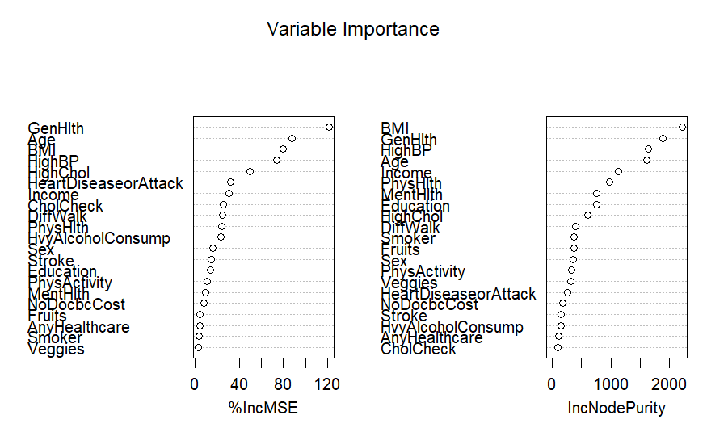

```r
# Plot the variable importance for the model
varImpPlot(rf_model, main = "Variable Importance")
```

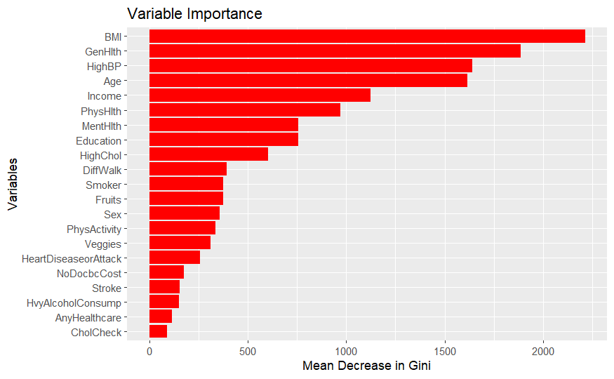

```r
rf_df <- as.data.frame(rf_model$importance)

# Plot the variable importance for the model using all the variables
ggplot(rf_df, aes(x = reorder(rownames(rf_df), IncNodePurity), y = IncNodePurity)) +
  geom_col(fill = "red") +
  coord_flip() +
  labs(x = "Variables", y = "Mean Decrease in Gini", title = "Variable Importance")
```

Using KNN:

```r
# Train and evaluate the K-nearest neighbors model
knn_model <- knn(train_data[, -1], test_data[, -1], train_data$Diabetes_binary, k = 5)
knn_predictions <- as.factor(knn_model)
knn_accuracy <- sum(knn_predictions == test_data$Diabetes_binary) / length(test_data$Diabetes_binary)
cat("Accuracy:", knn_accuracy, "\n")
```

```
Accuracy: 0.7129114
```

As we can see in the results of different models, the error (e.g. MSE or AIC) or variables importance after adding 9 features is significantly reduced. Moreover, the effect of the remaining feature on the error experiences a sudden decline. By Considering all the result, comparing them and also taking a look to the plots presented in the first part, we obtain the final features vector as follow:

```r
best_features = c("BMI", "HighBP", "GenHlth", "Age", "PhysHlth", "HighChol", "DiffWalk", "CholCheck", "HvyAlcoholConsump", "Diabetes_binary")

new_data = data[, best_features]
shuffled_data <- new_data[sample(nrow(data)), ]

# Split the shuffled data into training and testing sets
train_ratio <- 0.7  # Set the desired training set ratio
train_indices <- createDataPartition(shuffled_data$Diabetes_binary, p = train_ratio, list = FALSE)
train_data <- shuffled_data[train_indices, ]
test_data <- shuffled_data[-train_indices, ]
```

# logistic

```r
# Create a logistic regression model
logistic_model <- glm(Diabetes_binary ~ ., data = train_data, family = binomial)
logistic_predictions <- predict(logistic_model, newdata = test_data, type = "response")
summary_data <- summary(logistic_model)
print(summary_data)
```

```
Call:
glm(formula = Diabetes_binary ~ ., family = binomial, data = train_data)

Coefficients:
                   Estimate Std. Error z value Pr(>|z|)
(Intercept)       -7.543854   0.126136 -59.807  < 2e-16 ***
BMI                0.075055   0.001856  40.429  < 2e-16 ***
HighBP             0.747391   0.023369  31.982  < 2e-16 ***
GenHlth            0.635091   0.013041  48.701  < 2e-16 ***
Age                0.161479   0.004434  36.422  < 2e-16 ***
PhysHlth          -0.008187   0.001370  -5.978 2.26e-09 ***
HighChol           0.605054   0.022287  27.148  < 2e-16 ***
DiffWalk           0.185684   0.029812   6.229 4.71e-10 ***
CholCheck          1.400040   0.098958  14.148  < 2e-16 ***
HvyAlcoholConsump -0.791603   0.057689 -13.722  < 2e-16 ***
---
Signif. codes:  0 ‘***’ 0.001 ‘**’ 0.01 ‘*’ 0.05 ‘.’ 0.1 ‘ ’ 1

(Dispersion parameter for binomial family taken to be 1)

    Null deviance: 68602  on 49485  degrees of freedom
Residual deviance: 51119  on 49476  degrees of freedom
AIC: 51139

Number of Fisher Scoring iterations: 5
```

# LDA

```r
# Extract the predictor variables and the target variable from the train and test data
train_x <- train_data[, -1]
train_y <- train_data[, 1]
test_x <- test_data[, -1]
test_y <- test_data[, 1]
```

```r
library(MASS)
library(gmodels)
# Apply Linear Discriminant Analysis (LDA)
lda_model <- lda(train_x, train_y)

# Predict using LDA
lda_pred <- predict(lda_model, test_x)

# Calculate accuracy for LDA
lda_accuracy = sum(lda_pred$class == test_y) / length(test_y)

# Print the accuracies
cat("LDA Accuracy:", lda_accuracy, "\n")
```

```
LDA Accuracy: 0.08973875
```

```r
summary(lda_model)
```

```
        Length Class  Mode
prior    79    -none- numeric
counts   79    -none- numeric
means   711    -none- numeric
scaling  81    -none- numeric
lev      79    -none- character
svd       9    -none- numeric
N         1    -none- numeric
call      3    -none- call
```

not acceptabe!

# KNN

```r
# Train and evaluate the K-nearest neighbors model
knn_model <- knn(train_data[, -1], test_data[, -1], train_data$Diabetes_binary, k = 5)
knn_predictions <- as.factor(knn_model)
knn_accuracy <- sum(knn_predictions == test_data$Diabetes_binary) / length(test_data$Diabetes_binary)
print(knn_accuracy)
```

```
[1] 0.9925964
```

## ================================ Question 5 =================================

Given the application’s requirement for fast prediction, it is important to consider the computational efficiency of the models. Parametric models, such as logistic regression, can quickly predict diabetes by performing a simple mathematical operation once the model is trained. These models estimate the relationship between the features (the same questions asked to the user) and the target variable using predetermined parameters.

Another model worth considering is the decision tree. It is a parametric model that partitions the feature space into regions based on the provided features. Decision trees can be easily interpreted and understood. However, when selecting a model, it is crucial to consider not only its computational efficiency but also its accuracy and precision in classifying the data.

To evaluate the performance of the model, various metrics such as confusion matrix, F1-score, ROC curve, etc., can be utilized. It is essential to avoid overfitting or underfitting the model. Overfitting occurs when the model memorizes the training data, while underfitting happens when the model fails to capture the patterns in the data. Techniques like cross-validation, regularization, and pruning can be employed to address these issues and improve the model’s generalization.

By considering these factors – computational efficiency, accuracy, precision, and avoidance of overfitting/underfitting – we can choose the most suitable model for predicting diabetes based on the given set of features obtained from the user.